# Intensity

## Psychoacoustics of Intensity

### Chris Tralie

```python
import librosa
import numpy as np
import matplotlib.pyplot as plt
import IPython.display as ipd
```

Pitch is the perceptual analog to frequency

Intensity which is the perceptual analog to loudness

- Loudness (L) is defined in units of Watts/m^2
- $L \propto A^2 $; Loudness is proportional to amplitude squared

If we plot just the loudness over time of the female countdown, it's too noisy. So instead, we'll plot the average loudness over time within windows of length 2000, which we can compute quickly with the help of cumulative sum

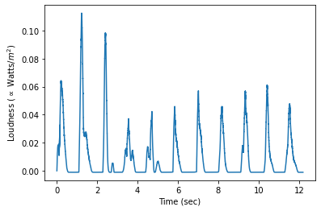

```python
y, sr = librosa.load("femalecountdown.mp3", sr=22050)
win = 2000
L = y**2
L = (np.cumsum(L[win::]) - np.cumsum(L[0:-win]))/win
t = np.arange(len(L))/sr
#plt.plot(t[(t<0.5) * (t > 0.4)], L[(t < 0.5) * (t > 0.4)])
plt.plot(t, L)
plt.xlabel("Time (sec)")
plt.ylabel("Loudness ($\propto$ Watts/$m^2$)")
```

### Intensity

Interestingly, we actually have to multiply the loudness by a factor of 10 to hear a doubling in intensity. So we define a decibel (dB) measure of intensity as follows:

## $ 10 \log_{10}(L/L_{th}) $

Where $L_{th} = 10^{-12}$ Watts/$m^2$ is the "threshold of hearing," which is quietest thing we can hear and is set to 0 as an absolute reference. Everything else will be higher than this.

We can write this equation in a few other ways by using rules of logarithms

$ 10 \log_{10} (L) + 120 $

$ 10 \log_{10} (A^2) + 120 $

$ 20 \log_{10} (A) + 120 $

Let's now plot the average intensity of the female countdown over time

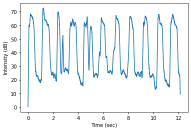

```python
y, sr = librosa.load("femalecountdown.mp3", sr=22050)
win = 2000
L = y**2
I = 10*np.log10(L) + 120
I = (np.cumsum(I[win::]) - np.cumsum(I[0:-win]))/win
t = np.arange(len(I))/sr
#plt.plot(t[(t<0.5) * (t > 0.4)], L[(t < 0.5) * (t > 0.4)])
plt.plot(t, I)
plt.xlabel("Time (sec)")
plt.ylabel("Intensity (dB)")
```

As we can see, when she speaks, her intensity is around that of what voice intensity should be

[figure not shown]

We can also use an intensity measure to measure the dynamics of a musical piece! In this case, we look at a part of the third movement to Tchaikovsky's 6th symphony. If we follow along the intensity, we can hear how it correlates to what the music is doing

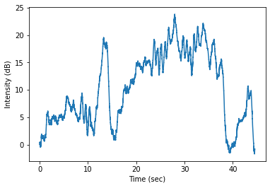

```python
y, sr = librosa.load("tchaik.mp3", sr=22050)
win = 10000
L = y**2
I = 10*np.log10(L) + 120
I = (np.cumsum(I[win::]) - np.cumsum(I[0:-win]))/win
t = np.arange(len(I))/sr
#plt.plot(t[(t<0.5) * (t > 0.4)], L[(t < 0.5) * (t > 0.4)])
plt.plot(t, I)
plt.xlabel("Time (sec)")
plt.ylabel("Intensity (dB)")
```

```python
ipd.Audio(y, rate=sr)
```

[interactive chart not shown]